# Lab #4

Kobe Pranivong; illimunobe | Yi Hang Khor; bobbykhor

3/22/2020

```r
library(readxl)
library(ggplot2)
library(dplyr)
library(magrittr)
library(tidyr)
```

### Part One: Cleaning Data

```r
# Load the data
defense <- read_excel('cyclonesFootball2019.xlsx', sheet = 'Defensive')
offense <- read_excel('cyclonesFootball2019.xlsx', sheet = 'Offensive')
biography <- read_excel('cyclonesFootball2019.xlsx', sheet = 'Biography')

# 1. The player names and opponents names are factors.
defense$Name %<>% factor
defense$Opponent_Opponent %<>% factor

offense$Name %<>% factor
offense$Opponent_Opponent %<>% factor

# 2. All offensive and defensive statistics are numerical. The Weight column in biogrpahy is also numeric. (Hint: look at ?mutate_at if you want to save writing some code).
newCols = c('Tackles_Solo', 'Tackles_ASST',  'Tackles_TFL', 'Tackles_Sack',  'Turnover_FF',   'Turnover_FR', 'Turnover_INT', 'Pass_QBH','Pass_PB')
defense[, newCols] %<>% lapply(function(x) as.numeric(as.character(x)))
defClean = defense

newCols1 = c('Rushing_ATT', 'Rushing_YDS', 'Rushing_TD','Receiving_REC',  'Receiving_YDS','Receiving_TD', 'Passing_CMP-ATT', 'Passing_YDS', 'Passing_TD', 'Passing_INT')
offense[, newCols1] %<>% lapply(function(x) as.numeric(as.character(x)))
offClean = offense

# 3. Change the Height column in biography into numeric. (Hint: Use a unit that works well)
biography$Name %<>% factor
biography$Position %<>% factor
biography[["Height"]] <- gsub('-', '.', biography$Height)
newCols2 = c('Weight', 'Height')
biography[, newCols2] %<>% lapply(function(x) as.numeric(as.character(x)))
bioClean = biography

# Print the structures of defClean, offClean, bioClean.
head(defClean)
```

```
## # A tibble: 6 x 11
##   Name  Opponent_Oppone~ Tackles_Solo Tackles_ASST Tackles_TFL Tackles_Sack
##   <fct> <fct>                   <dbl>        <dbl>       <dbl>        <dbl>
## 1 Whit~ UNI                         4            4           0            0
## 2 Whit~ Iowa                        4            7           0            0
## 3 Whit~ ULM                         3            5           0            0
## 4 Whit~ Baylor                      4            2           0            0
## 5 Whit~ TCU                         3            2           1            0
## 6 Whit~ West Virginia               1            1           0            0
## # ... with 5 more variables: Turnover_FF <dbl>, Turnover_FR <dbl>,
## #   Turnover_INT <dbl>, Pass_QBH <dbl>, Pass_PB <dbl>
```

```r
head(offClean)
```

```
## # A tibble: 6 x 12
##   Name  Opponent_Oppone~ Rushing_ATT Rushing_YDS Rushing_TD Receiving_REC
##   <fct> <fct>                  <dbl>       <dbl>      <dbl>         <dbl>
## 1 Aker~ UNI                        0           0          0             1
## 2 Aker~ Iowa                       0           0          0             0
## 3 Aker~ ULM                        1           8          0             0
## 4 Aker~ Baylor                     0           0          0             0
## 5 Aker~ TCU                        0           0          0             1
## 6 Aker~ West Virginia              0           0          0             0
## # ... with 6 more variables: Receiving_YDS <dbl>, Receiving_TD <dbl>,
## #   `Passing_CMP-ATT` <dbl>, Passing_YDS <dbl>, Passing_TD <dbl>,
## #   Passing_INT <dbl>
```

```r
head(bioClean)
```

```
## # A tibble: 6 x 7
##   Name          Position     Height Weight Class       Hometown       Highschool
##   <fct>         <fct>         <dbl>  <dbl> <chr>       <chr>          <chr>
## 1 Akers, Landen Wide Receiv~    6      188 Redshirt S~ Cedar Rapids,~ Washington
## 2 Allen, Chase  Tight End       6.7    245 Redshirt S~ Nixa, Mo.      Nixa
## 3 Anderson, Ez~ Wide Receiv~    6.5    204 Redshirt F~ Seffner, Fla.  Armwood
## 4 Assalley, Co~ Placekicker     6      195 Redshirt S~ Naperville, I~ Central
## 5 Azunna, Arno~ Defensive B~    6      190 Redshirt S~ Grand Prairie~ Lake Ridge
## 6 Bailey, Cord~ Defensive E~    6.3    235 Redshirt J~ Clarksdale, M~ Clarksdale
```

### Part Two: Tidying (1)

1. Reformat the defClean data frame into a tidy format using pivot_longer. The type of statistic (Tackles_Solo, Tackles_ASST, etc) is added as a new key column named Statistic.

```r
defClean_pivot <- defClean %>%
  pivot_longer(Tackles_Solo:Pass_PB,names_to = "Statistic", values_to = "Number")
```

2. Create a histogram for each defensive statistic. Use facet_wrap to draw all histograms in a single plot. What defensive skills are rare?

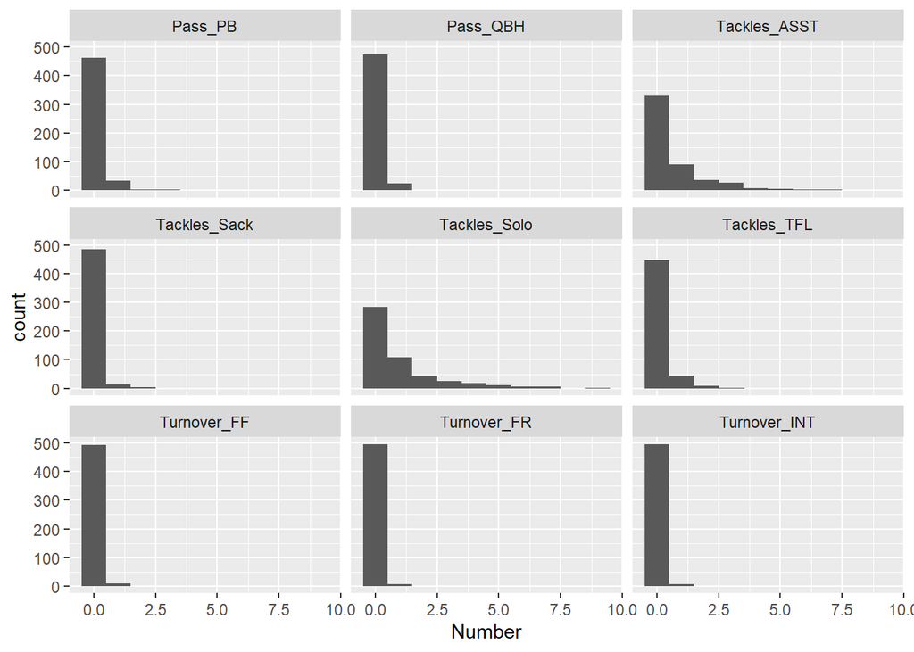

```r
ggplot(data = defClean_pivot, aes(x = Number)) + facet_wrap(~Statistic) + geom_histogram() + stat_bin(bins = 10)
```

Based on all of the histograms of the various defensive statistics we can see that very few players have at least 1 Turnover_FF, Turnover_FR and Turnover_INT; therefore, these are the rarest defensive skills.

3. Did ISU have better defense against West Virginia or Kansas State? Answer this question by creating a scatterplot with x-axis being the number of solo tackles (by each player) against West Virginia, and y-axis being that against Kansas State. A large number of solo tackles indicates good defense.

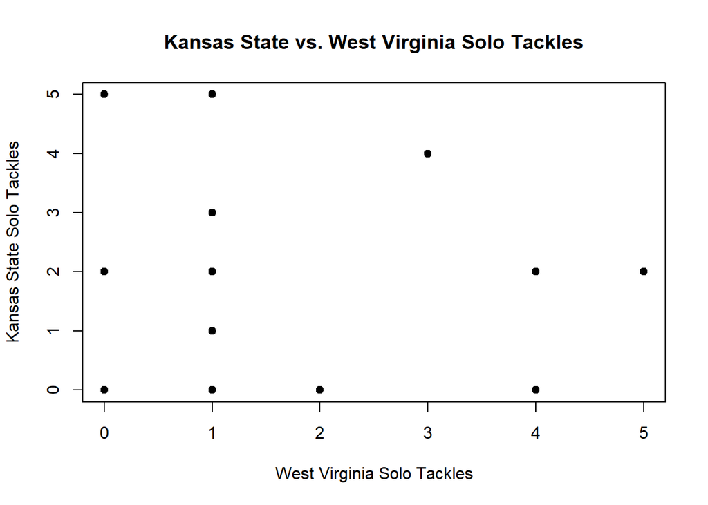

```r
df <- defClean_pivot
# Subset the data frame
df_virginia <- subset(df, ((Opponent_Opponent == "West Virginia") & (Statistic == "Tackles_Solo")) , select = c("Name", "Opponent_Opponent", "Number"))
df_kansas <- subset(df, ((Opponent_Opponent == "Kansas State") & (Statistic == "Tackles_Solo")) , select = c("Name", "Opponent_Opponent", "Number"))
df_new <- subset(df, ((Opponent_Opponent == "West Virginia") & (Statistic == "Tackles_Solo")) | ((Opponent_Opponent == "Kansas State") & (Statistic == "Tackles_Solo")) , select = c("Name", "Opponent_Opponent", "Number"))
# Keep the names that are in both data frames
keep <- intersect(df_virginia$Name, df_kansas$Name)
df_virginia <- df_virginia[df_virginia$Name %in% keep, ]
df_kansas <- df_kansas[df_kansas$Name %in% keep, ]
# Check if lengths are equal.
# length(df_ks) == length(df_wv)
# Plot West Virginia in the x-axis and Kansas in the y-axis
plot(df_virginia$Number, df_kansas$Number, main="Kansas State vs. West Virginia Solo Tackles",
   xlab = "West Virginia Solo Tackles", ylab = "Kansas State Solo Tackles", pch = 19)
```

### Part Two: Tidying(2)

1. Separate the Hometown column into two columns, namely the city and the state. Print the first few rows of these two columns. (Hint: look at the sep = argument of separate)

```r
bioClean_tidy <- bioClean %>%
  separate('Hometown', c("Home_City", "Home_State"), sep = ", (?=[^ ]+$)")
bioClean_tidy %>% head(5)
```

```
## # A tibble: 5 x 8
##   Name       Position   Height Weight Class     Home_City  Home_State Highschool
##   <fct>      <fct>       <dbl>  <dbl> <chr>     <chr>      <chr>      <chr>
## 1 Akers, La~ Wide Rece~    6      188 Redshirt~ Cedar Rap~ Iowa       Washington
## 2 Allen, Ch~ Tight End     6.7    245 Redshirt~ Nixa       Mo.        Nixa
## 3 Anderson,~ Wide Rece~    6.5    204 Redshirt~ Seffner    Fla.       Armwood
## 4 Assalley,~ Placekick~    6      195 Redshirt~ Naperville Ill.       Central
## 5 Azunna, A~ Defensive~    6      190 Redshirt~ Grand Pra~ Texas      Lake Ridge
```

2. How many players are there from each state?

```r
bioClean_tidy %>%
  group_by(Home_State) %>%
  summarize(Count = n())
```

```
## # A tibble: 19 x 2
##    Home_State Count
##    <chr>      <int>
##  1 Ariz.          4
##  2 Ark.           1
##  3 Australia      1
##  4 Calif.         3
##  5 Fla.          10
##  6 Ga.            4
##  7 Ill.           5
##  8 Iowa          35
##  9 Kan.           3
## 10 Mich.          4
## 11 Minn.          4
## 12 Miss.          1
## 13 Mo.            6
## 14 Ohio           7
## 15 Okla.          2
## 16 Pa.            1
## 17 S.D.           2
## 18 Texas          6
## 19 Wis.           6
```

### Part Three: Joining Data Frames

1. Find where do the offensive players come from by joining the offensive data and player biography data appropriately.

```r
unique_offense = unique(offClean$Name)
offensive_bio <- bioClean_tidy[bioClean_tidy$Name %in% unique_offense, ]
offensive_bio <- subset(offensive_bio, select = c("Name","Home_City", "Home_State", "Highschool"))
offensive_bio
```

```
## # A tibble: 13 x 4
##    Name            Home_City     Home_State Highschool
##    <fct>           <chr>         <chr>      <chr>
##  1 Akers, Landen   Cedar Rapids  Iowa       Washington
##  2 Allen, Chase    Nixa          Mo.        Nixa
##  3 Brock, Jirehl   Quincy        Ill.       Quincy
##  4 Hall, Breece    Wichita       Kan.       Northwest
##  5 Kolar, Charlie  Norman        Okla.      North
##  6 Lang, Johnnie   Palmetto      Fla.       Salt Lake City East {Utah}
##  7 Milton, Tarique Bradenton     Fla.       Manatee
##  8 Nwangwu, Kene   Frisco        Texas      Heritage
##  9 Purdy, Brock    Gilbert       Ariz.      Perry
## 10 Scates, Joe     Dayton        Ohio       Dunbar
## 11 Shaw Jr., Sean  Jones         Okla.      Jones
## 12 Soehner, Dylan  Prairie Grove Ark.       Prairie Grove
## 13 Wilson, Darren  Alpharetta    Ga.        Cambridge
```

2. Is there a relationship between the weight of a player and the receiving yards (Receiving_YDS)?

```r
correlation = inner_join(bioClean, offClean, by = "Name") %>%
  select(Name, Weight, Receiving_YDS) %>%
  group_by(Name) %>%
  mutate(mean_yds = mean(Receiving_YDS))
```

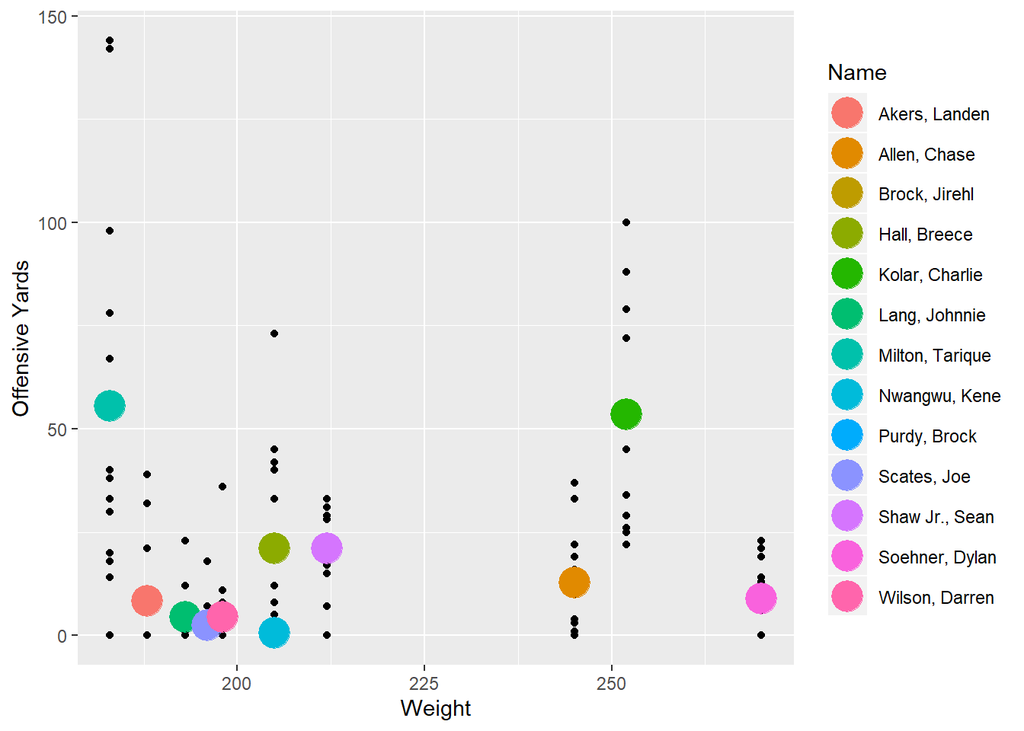

```r
# Plotting the data
ggplot(distinct(correlation, Name, .keep_all=TRUE), aes(x = Weight, y = mean_yds, color = Name)) + ylab("Offensive Yards") +
  geom_point(data = correlation, aes(x = Weight, y = Receiving_YDS), show.legend = TRUE, inherit.aes = FALSE) + geom_point(size = 7)
```

3. How do the performance of quarterback Brock Purdy relate to the performance of the ISU team?

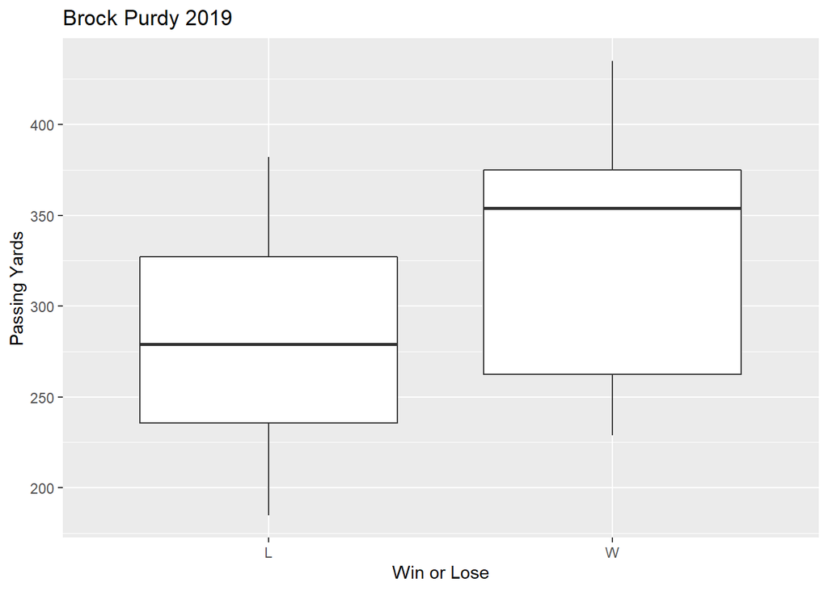

```r
brock <- offClean
brock <- subset(brock, (brock$Name == "Purdy, Brock"), select = c("Name","Opponent_Opponent",  "Passing_YDS", "Passing_TD", "Passing_INT"))
isu_record <- c("W","L","W","L","W","W","W","L","L","W","W","L","L")
brock$Team_Record=isu_record
ggplot(brock, aes(x = Team_Record, y = Passing_YDS)) + geom_boxplot() + labs(title = "Brock Purdy 2019", x = "Win or Lose", y = "Passing Yards")
```

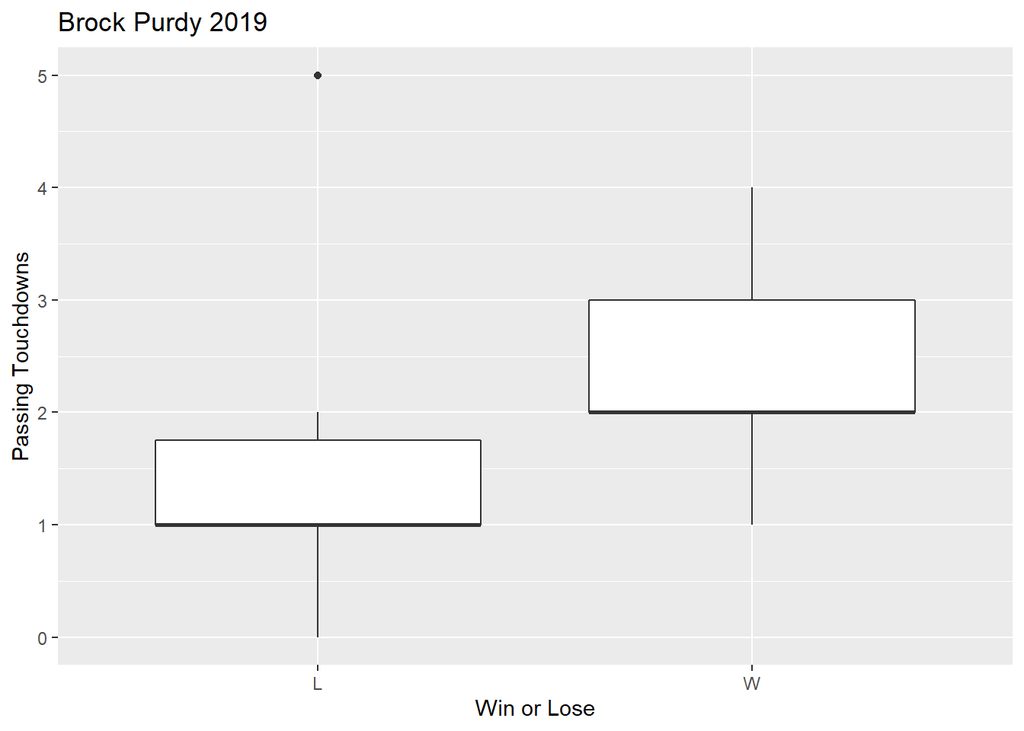

```r
ggplot(brock, aes(x = Team_Record, y = Passing_TD)) + geom_boxplot() + labs(title = "Brock Purdy 2019", x = "Win or Lose", y = "Passing Touchdowns")
```

Since Brock Purdy is a quarterback, a player that typically holds the ball for the longest time, if his performance is good, then his team has a better chance of victory. Based on the boxplots that compared the passing yards and passing touchdowns of Brock Purdy when ISU won and lost, we can see that when ISU won, he tended to throw more passing yards and touchdowns. This means that Brock Purdy’s performance has a positive impact on the performance of the ISU team. However, we must take a look at one outlier in the passing touchdowns boxplots. In this data, Brock Purdy threw 5 touchdowns, but the ISU team still loss. This most likely means that although he performed splendidly, the ISU team’s defense must’ve had very bad performance.

### 4.) Explore more. You may in addition explore the 2018 data here. Raise a question that can be answered only by looking at two or more data frames. Then answer that question.

### By comparing 2018 and 2019 data, will the height of a player influence the receiving yards?

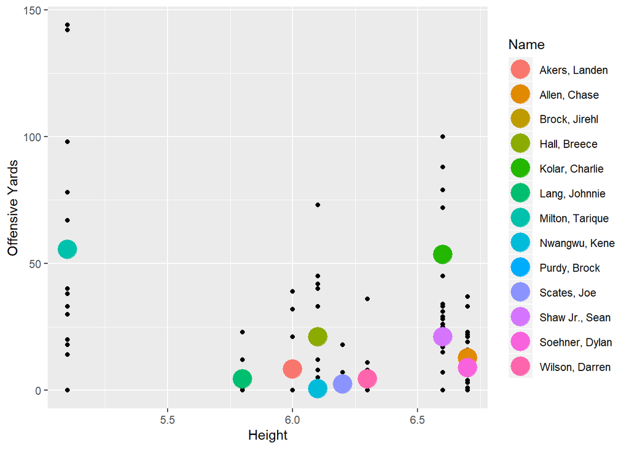

```r
offense2 <- read_excel('cyclonesFootball2018.xlsx', sheet = 'Offensive')
biography2 <- read_excel('cyclonesFootball2018.xlsx', sheet = 'Biography')

offense2$Name %<>% factor
offense2$Opponent_Opponent %<>% factor
newCols1b = c('Rushing_ATT', 'Rushing_YDS', 'Rushing_TD','Receiving_REC',  'Receiving_YDS','Receiving_TD', 'Passing_CMP-ATT', 'Passing_YDS', 'Passing_TD', 'Passing_INT')
offense2[, newCols1b] %<>% lapply(function(x) as.numeric(as.character(x)))
offClean2 = offense2

biography2$Name %<>% factor
biography2$Position %<>% factor
biography2[["Height"]] <- gsub('-', '.', biography2$Height)
newCols2b = c('Weight', 'Height')
biography2[, newCols2b] %<>% lapply(function(x) as.numeric(as.character(x)))
bioClean2 = biography2

correlation = inner_join(bioClean, offClean, by = "Name") %>%
  select(Name, Height, Receiving_YDS) %>%
  group_by(Name) %>%
  mutate(mean_yds = mean(Receiving_YDS))
ggplot(distinct(correlation, Name, .keep_all=TRUE), aes(x = Height, y = mean_yds, color = Name)) + ylab("Offensive Yards") +
  geom_point(data = correlation, aes(x = Height, y = Receiving_YDS), show.legend = TRUE, inherit.aes = FALSE) + geom_point(size = 7)
```

```r
correlation2 = inner_join(bioClean2, offClean2, by = "Name") %>%
  select(Name, Height, Receiving_YDS) %>%
  group_by(Name) %>%
  mutate(mean_yds = mean(Receiving_YDS))
```

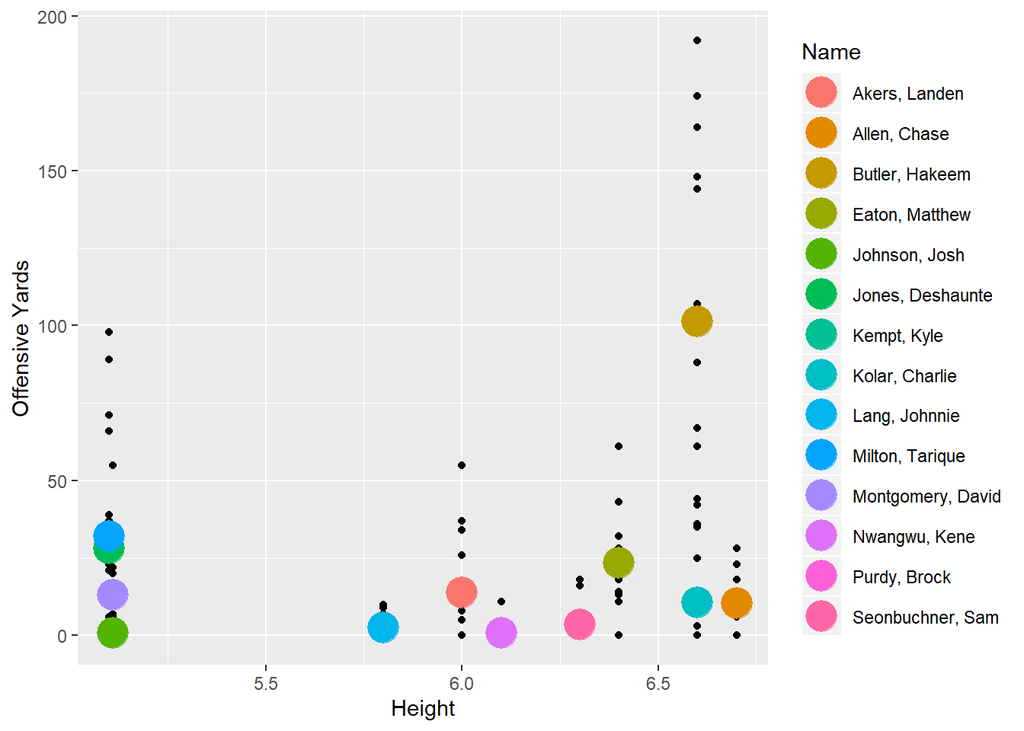

```r
ggplot(distinct(correlation2, Name, .keep_all=TRUE), aes(x = Height, y = mean_yds, color = Name)) + ylab("Offensive Yards") +
  geom_point(data = correlation2, aes(x = Height, y = Receiving_YDS), show.legend = TRUE, inherit.aes = FALSE) + geom_point(size = 7)
```